# Digital Marketing Regression

## Linear Regression

Linear regression (or linear model) is used to predict a quantitative outcome variable (y) on the basis of one or multiple predictor variables (x) (James et al. 2014,P. Bruce and Bruce (2017)).

The goal is to build a mathematical formula that defines y as a function of the x variable. Once, we built a statistically significant model, it’s possible to use it for predicting future outcome on the basis of new x values.

The marketing data set included with package datarium is used to create a model for predicting sales units on the basis of the amount of money spent in the 3 advertising medias (youtube, facebook and newspaper)

```r
 #install.packages('datarium')
library(dplyr, warn.conflicts = FALSE) # suppress conflicts warning

# Load the data
data("marketing", package = "datarium")

# top 5 observations
head(marketing, 5)
```

|  | youtube | facebook | newspaper | sales |
| --- | --- | --- | --- | --- |
| 1 | 276.12 | 45.36 | 83.04 | 26.52 |
| 2 | 53.40 | 47.16 | 54.12 | 12.48 |
| 3 | 20.64 | 55.08 | 83.16 | 11.16 |
| 4 | 181.80 | 49.56 | 70.20 | 22.20 |
| 5 | 216.96 | 12.96 | 70.08 | 15.48 |

## Multiple Linear Regression

```r
options(width = 400) # increase width

# correlation
corr <- round(cor(marketing), 2)
corr
```

```
##           youtube facebook newspaper sales
## youtube      1.00     0.05      0.06  0.78
## facebook     0.05     1.00      0.35  0.58
## newspaper    0.06     0.35      1.00  0.23
## sales        0.78     0.58      0.23  1.00
```

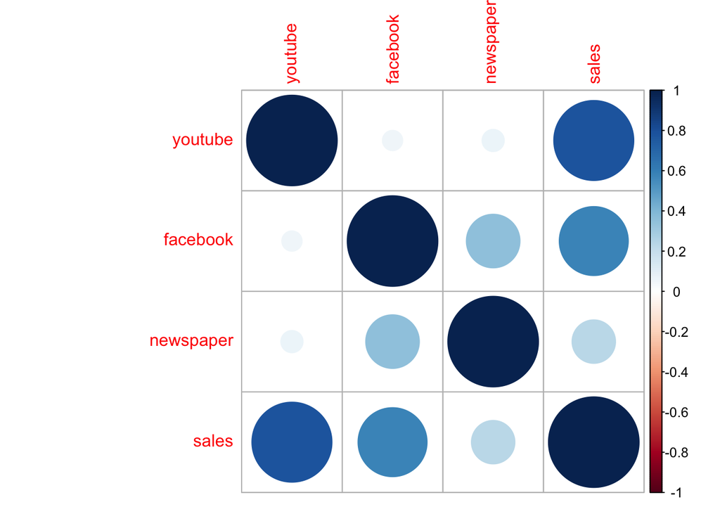

```r
library(corrplot)
corrplot(corr, method="circle")
```

We see that youtube (.78) and facebook (.58) contribute the most to sales while news paper (0.23) much less. Create a model with variables youtube and facebook.

```r
model <- lm(sales ~ youtube + facebook, data = marketing)

# show model summary
summary(model)
```

```
##
## Call:
## lm(formula = sales ~ youtube + facebook, data = marketing)
##
## Residuals:
##      Min       1Q   Median       3Q      Max
## -10.5572  -1.0502   0.2906   1.4049   3.3994
##
## Coefficients:
##             Estimate Std. Error t value Pr(>|t|)
## (Intercept)  3.50532    0.35339   9.919   <2e-16 ***
## youtube      0.04575    0.00139  32.909   <2e-16 ***
## facebook     0.18799    0.00804  23.382   <2e-16 ***
## ---
## Signif. codes:  0 '***' 0.001 '**' 0.01 '*' 0.05 '.' 0.1 ' ' 1
##
## Residual standard error: 2.018 on 197 degrees of freedom
## Multiple R-squared:  0.8972, Adjusted R-squared:  0.8962
## F-statistic: 859.6 on 2 and 197 DF,  p-value: < 2.2e-16
```

easier viewing of coefficients using broom

```r
library(broom)
```

```r
tidy(model)
```

| term | estimate | std.error | statistic | p.value |
| --- | --- | --- | --- | --- |
| (Intercept) | 3.50531989 | 0.353387614 | 9.919193 | 4.565557e-19 |
| youtube | 0.04575482 | 0.001390356 | 32.908708 | 5.436980e-82 |
| facebook | 0.18799423 | 0.008039973 | 23.382446 | 9.776972e-59 |

1. The model equation: sales = 3.50+ 0.045(youtube) + 0.187(facebook).
2. The intercept (eg: constant) is the expected mean value of Y when all X=0. In this case 3.50
3. All have significant t-statistic values with significant p-values
4. For a one unit increase in youtube marketing we can expect a 0.045 increase in sales
5. For a one unit increase in facebook marketing we can expect a 0.187 increase in sales

**The Adjusted R-squared (0.896) indicates that about 90% of Sales is explained by this model.**

## Including all variables

Suppose we create a model with all variables

```r
model <- lm(sales ~. , data = marketing) # include all variables
summary(model)
```

```
##
## Call:
## lm(formula = sales ~ ., data = marketing)
##
## Residuals:
##      Min       1Q   Median       3Q      Max
## -10.5932  -1.0690   0.2902   1.4272   3.3951
##
## Coefficients:
##              Estimate Std. Error t value Pr(>|t|)
## (Intercept)  3.526667   0.374290   9.422   <2e-16 ***
## youtube      0.045765   0.001395  32.809   <2e-16 ***
## facebook     0.188530   0.008611  21.893   <2e-16 ***
## newspaper   -0.001037   0.005871  -0.177     0.86
## ---
## Signif. codes:  0 '***' 0.001 '**' 0.01 '*' 0.05 '.' 0.1 ' ' 1
##
## Residual standard error: 2.023 on 196 degrees of freedom
## Multiple R-squared:  0.8972, Adjusted R-squared:  0.8956
## F-statistic: 570.3 on 3 and 196 DF,  p-value: < 2.2e-16
```

**From the output, we confirm that the variable newspaper is not statistically significant to the model with a p-value of (0.86)**